# Using GeDi on the T cell dataset (GSE130842)

Annekathrin Silvia Nedwed

Institute of Medical Biostatistics, Epidemiology and Informatics (IMBEI), Mainz  
anedwed@uni-mainz.de

Arsenij Ustjanzew

Institute of Medical Biostatistics, Epidemiology and Informatics (IMBEI), Mainz

Najla Abassi

Institute of Medical Biostatistics, Epidemiology and Informatics (IMBEI), Mainz

Leon Dammer

Institute of Medical Biostatistics, Epidemiology and Informatics (IMBEI), Mainz

Alicia Schulze

Institute of Medical Biostatistics, Epidemiology and Informatics (IMBEI), Mainz

Sara Salome Helbich

Institute of Immunology, University Medical Center Mainz, Mainz, Germany  
Research Center for Immunotherapy (FZI), Mainz, Germany

Michael Delacher

Institute of Immunology, University Medical Center Mainz, Mainz, Germany  
Research Center for Immunotherapy (FZI), Mainz, Germany

Konstantin Strauch

Institute of Medical Biostatistics, Epidemiology and Informatics (IMBEI), Mainz

Federico Marini

Institute of Medical Biostatistics, Epidemiology and Informatics (IMBEI), Mainz  
Research Center for Immunotherapy (FZI), Mainz, Germany  
Center for Thrombosis and Hemostasis (CTH), Mainz  
marinif@uni-mainz.de

22 July 2025

# 1 About the data

The data illustrated in this document is an RNA-seq dataset, available at the Gene Expression Omnibus under the accession code GSE130842.

# 2 Loading required packages

We load the packages required to perform all the analytic steps presented in this document.

```r
library("DESeq2")
library("topGO")
library("pcaExplorer")
library("ideal")
library("GeneTonic")
library("apeglm")
library("dplyr")
library("msigdbr")
library("visNetwork")
library("org.Mm.eg.db")
library("GeDi")
library("ggplot2")
library("visNetwork")
library("utils")
library("ComplexHeatmap")
```

# 3 Data processing

In this example we analyse data available on the Gene Expression Omnibus under accession number GSE130842. From the available data, we downloaded the GSE130842_Count_table_Delacher_et_al_2019.xlsx Excel file, which is also available in the [Github](https://github.com/AnnekathrinSilvia/GeDi_supplement) repository to this document.

We will preprocess the data for its use in *Gedi* according to the workflow described in the package vignette of *Gedi*. The package vignette is available through using the command `browseVignette(GeDi)` after successfully installing the package.

In the first step of the preprocessing, we will generate a `DESeqDataset` (Love, Huber, and Anders 2014) from the count table available in the Excel file. We will further preprocess this object, called `dds_tregs`, to prepare the data for its use in `GeDi`. We will also read in some metadata that we have set up for the dataset. This file will also be available in the [repository](https://github.com/AnnekathrinSilvia/GeDi_supplement) as well as the final generated `dds_tregs`.

```r
# We read in the data form the Excel file
count_df <- readxl::read_excel("GSE130842_Count_table_Delacher_et_al_2019.xlsx")

# We transform the data into a matrix and set the gene ids as the rownames of
# the final matrix
count_matrix <- as.matrix(count_df[, -1])
rownames(count_matrix) <- count_df$ID

# We read in the metadata
coldata <- readxl::read_excel("GSE130842_metadata.xlsx")
coldata
```

```
## # A tibble: 56 × 5
##    ID_GEO                      group                    group2     rep_nr tissue
##    <chr>                       <chr>                    <chr>       <dbl> <chr>
##  1 Klrg1-Il1rl1-Treg_BM_R1     Klrg1-Il1rl1-Treg_BM     Klrg1-Il1…      1 bonem…
##  2 Klrg1-Il1rl1-Treg_BM_R2     Klrg1-Il1rl1-Treg_BM     Klrg1-Il1…      2 bonem…
##  3 Klrg1-Il1rl1-Treg_BM_R3     Klrg1-Il1rl1-Treg_BM     Klrg1-Il1…      3 bonem…
##  4 Klrg1-Il1rl1-Treg_BM_R4     Klrg1-Il1rl1-Treg_BM     Klrg1-Il1…      4 bonem…
##  5 Klrg1-Il1rl1-Treg_Spleen_R1 Klrg1-Il1rl1-Treg_Spleen Klrg1-Il1…      1 spleen
##  6 Klrg1-Il1rl1-Treg_Spleen_R2 Klrg1-Il1rl1-Treg_Spleen Klrg1-Il1…      2 spleen
##  7 Klrg1-Il1rl1-Treg_Spleen_R3 Klrg1-Il1rl1-Treg_Spleen Klrg1-Il1…      3 spleen
##  8 Klrg1-Il1rl1-Treg_Spleen_R4 Klrg1-Il1rl1-Treg_Spleen Klrg1-Il1…      4 spleen
##  9 tisTregST2_BM_R1            tisTregST2_BM            tisTregST2      1 bonem…
## 10 tisTregST2_BM_R2            tisTregST2_BM            tisTregST2      2 bonem…
## # ℹ 46 more rows
```

```r
# We build up the DESeqDataset object from the count data and the metadata
# As design we will choose the group of the data which indicates the tissue
# of origin as well as t5he type of Tcells in the sample
dds_tregs <- DESeqDataSetFromMatrix(
  countData = count_matrix,
  colData = coldata,
  design = ~group
)

# We transform the columnnames of the dds_tregs to include the replicate number
# of each sample
colnames(dds_tregs) <- paste0(coldata$group, "_r", coldata$rep_nr)

# Lastly we can have a look at our DESeqDataset object
dds_tregs
```

```
## class: DESeqDataSet
## dim: 52550 56
## metadata(1): version
## assays(1): counts
## rownames(52550): ENSMUSG00000000001 ENSMUSG00000000003 ...
##   ENSMUSG00000114967 ENSMUSG00000114968
## rowData names(0):
## colnames(56): Klrg1-Il1rl1-Treg_BM_r1 Klrg1-Il1rl1-Treg_BM_r2 ...
##   Treg_IL2_r3 Treg_IL2_r4
## colData names(5): ID_GEO group group2 rep_nr tissue
```

Now we can see that we have set up a `DESeqDataset` object on all the available samples. However, in this analysis, we will only focus on a subset of samples. Hence, we will subset our `dds_tregs` object to the groups used in the figure.

```r
dds_tregs <- dds_tregs[, dds_tregs$group %in%
                          c("KLRGminusNFIL3minusTreg" ,
                            "KLRGplusNFIL3plusTreg")]

dds_tregs$group <- droplevels(dds_tregs$group)
design(dds_tregs) <- ~group
```

## 3.1 Exploratory data analysis

In a first analysis step, we do an exploratory data analysis as described in (Ludt et al. 2022) using the *pcaExplorer* package (Marini and Binder 2019).

We will first apply a variance-stabilizing transformation before we plot a PCA and a sample-to-sample distance heatmap.

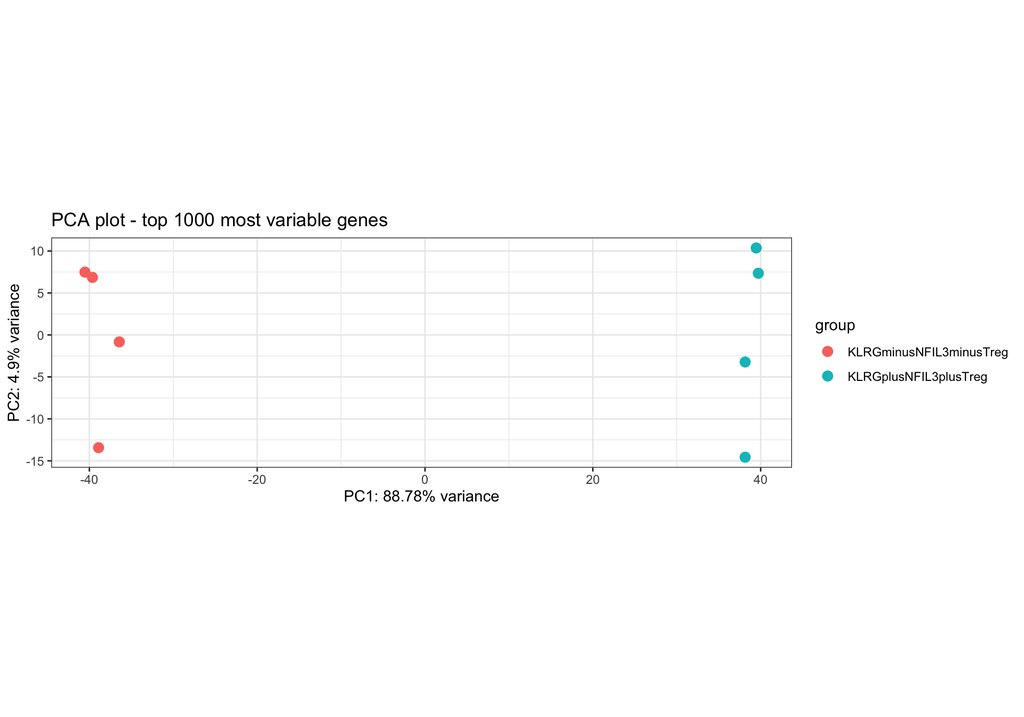

```r
# Apply the vst transformation
vst_tregs <- vst(dds_tregs)

# Plot the PCA
pcaExplorer::pcaplot(vst_tregs,
                     intgroup = "group",
                     ntop = 1000,
                     title = "PCA plot - top 1000 most variable genes",
                     ellipse = FALSE,
                     text_labels = FALSE
                     )
```

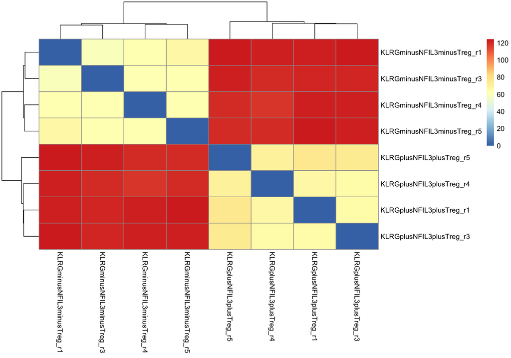

```r
# Plot a sampl-to-sample distance heatmap
pheatmap::pheatmap(as.matrix(dist(t(assay(vst_tregs)))))
```

## 3.2 Differential expression analysis

After we have done some exploratory data analysis, we can proceed with the differential expression analysis. We use the *DESeq2* package (Love, Huber, and Anders 2014) for this. The False Discovery Rate is set to 5%.

Before, we run the *DESeq2* analysis, we first match the gene ids to gene names using the *pcaExplorer* package (Marini and Binder 2019). With this we can add the gene names to the results, which are usually better known than gene ids. The gene names will also be later used as “Genes” column in the input for *GeDi*.

```r
# Create an annodation data frame mapping gene ids to gene names.
anno_df <- pcaExplorer::get_annotation_orgdb(dds_tregs,"org.Mm.eg.db","ENSEMBL")
# Assign a new column SWYMBOL to the dds_tregs object, which will be later used
# as "Genes" column in the input for GeDi
rowData(dds_tregs)$SYMBOL <- anno_df$gene_name[match(rownames(dds_tregs),
                                                     anno_df$gene_id)]

# Set the false discovery rate to 5%
FDR <- 0.05

# Perform the differential gene expression analysis
dds_tregs <- DESeq(dds_tregs)
```

After we performed the analysis, we extract the results for the condition `KLRGplusNFIL3plusTreg vs KLRGminusNFIL3minusTreg`. Afterwards we print a summary overview of the previously extracted results.

We also use the *ideal* package (Marini, Linke, and Binder 2020) to plot an MA-plot of the results.

In a last step, we add the gene symbols to the resulting `DataFrame` which will later serve as our “Genes” column in the input data to `GeDi`.

```r
# Extract differentially expressed genes
# Perform contrast analysis comparing "KLRGplusNFIL3plusTreg" group to "KLRGminusNFIL3minusTreg" group
# Set a log2 fold change threshold of 1 and a significance level (alpha) of 0.05
res_tregs <- results(dds_tregs,
  contrast = c("group", "KLRGplusNFIL3plusTreg", "KLRGminusNFIL3minusTreg"),
  lfcThreshold = 1, alpha = 0.05
)

# Print a summary overview of the results
summary(res_tregs)
```

```
##
## out of 37267 with nonzero total read count
## adjusted p-value < 0.05
## LFC > 1.00 (up)    : 1167, 3.1%
## LFC < -1.00 (down) : 369, 0.99%
## outliers [1]       : 96, 0.26%
## low counts [2]     : 7776, 21%
## (mean count < 1)
## [1] see 'cooksCutoff' argument of ?results
## [2] see 'independentFiltering' argument of ?results
```

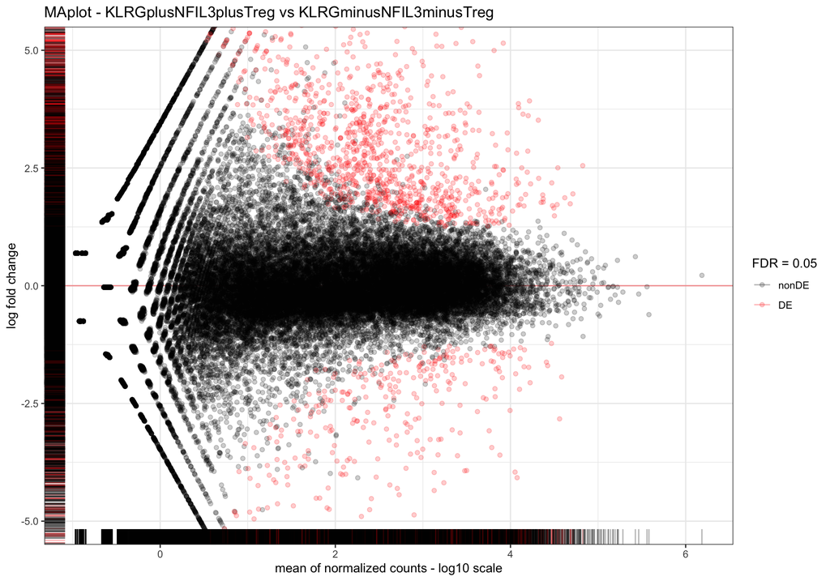

```r
# Plot an MA-plot of the results
ideal::plot_ma(res_tregs,
               ylim = c(-5, 5),
               title = "MAplot - KLRGplusNFIL3plusTreg vs KLRGminusNFIL3minusTreg")
```

```r
# Add gene symbols to the results in a column "SYMBOL"
res_tregs$SYMBOL <- rowData(dds_tregs)$SYMBOL
```

## 3.3 Functional enrichment analysis

Following the differential expression analysis, we perform a functional enrichment analysis using the *topGO* package (Alexa and Rahnenfuhrer 2024). Before the analysis, we first determine the set of background genes to be used, which in our case will be the set of expressed genes in the data. We also transform the results of our DE analysis to fit the format expectation of the `topGOtable` function from the *pcaExplorer* package (Marini and Binder 2019).

```r
# Determine the set of background genes as all genes expressed in the dataset
geneUniverseExpr <- rowData(dds_tregs)$SYMBOL[rowSums(counts(dds_tregs)) > 0]

# Extract gene symbols from the DESeq2 results object where FDR is below 0.05
# The function deseqresult2df is used to convert the DESeq2 results to a
# dataframe format
# FDR is set to 0.05 to filter significant results
de_symbols <- deseqresult2df(res_tregs, FDR = 0.05)$SYMBOL

# Perform Gene Ontology enrichment analysis using the topGOtable function from
# the "pcaExplorer" package
topGO_tregs <- topGOtable(
  DEgenes = de_symbols,
  BGgenes = geneUniverseExpr,
  ontology = "BP",
  geneID = "symbol",
  addGeneToTerms = TRUE,
  mapping = "org.Mm.eg.db",
  topTablerows = 500
)
```

## 3.4 Preparing the data for GeDi

After we have performed the functional enrichment analysis, the data is almost ready to be used with *GeDi*. However, in its current state the data is not yet in the correct format expected by *GeDi*. *GeDi* expects the data to have at least two columns, one named “Genesets” containing some form of geneset identifiers and one named “Genes” containing a list of genes belonging to the genesets. While this is not strictly necessary to use *GeDi* on the data, it facilitates the use of the app as the app can be used straight away instead of having to wait for the data to be reformatted. The correct data format is however necessary, if you want to use the data as a parameter as in `GeDi(topGO_tregs)`.

Nevertheless, we want to show you here, how to adapt the data from the *topGO* analysis to fit the data format requirements of *GeDi*. For this we simply have to rename the ‘GO.ID’ and the ‘genes’ column of the results as these two columns already contain the input data in the correct format.

```r
# Rename columns in the topGO_tregs dataframe
# Change the column name "GO.ID" to "Genesets"
names(topGO_tregs)[names(topGO_tregs) == "GO.ID"] <- "Genesets"

# Change the column name "genes" to "Genes"
names(topGO_tregs)[names(topGO_tregs) == "genes"] <- "Genes"
```

After we have renamed the columns, the data is now ready to be used in *GeDi*.

# 4 Running `GeDi` on the dataset

Now we can start to explore our data using *GeDi*. For this you can either follow the chunks in this document to prepare the data or we can load the prepared object provided with the [repository](https://github.com/AnnekathrinSilvia/GeDi_supplement) of this document.

```r
tregs_example <- readRDS("usecase_tregs_example.RDS")
```

Once we have loaded the data, we can start the app and interactively explore the data set using:

```r
GeDi(genesets = tregs_example)
```

Once the app is started, you can have interactive guidance of the user interface and its features by using the introductory tours of each panel of the app.

## 4.1 Using `GeDi`’s functions in analysis reports

The functionality of *GeDi* can be used also as standalone functions, to be called for example in existing analysis reports in RMarkdown, or R scripts.

In the following chunks, we show how it is possible to call some of the functions on the dataset presented in this document, for example to generate the contents of Figure 2 of the manuscript.

For this we first prepare the data.

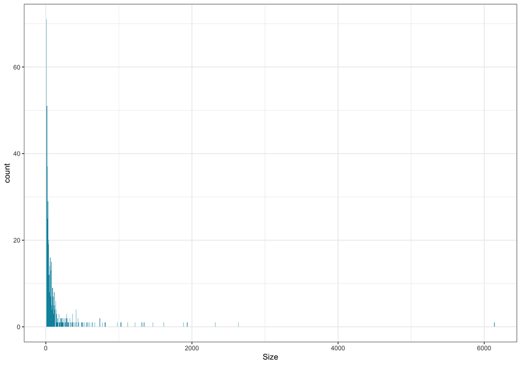

```r
# First we extract a representation of all genes in the data
genes <- GeDi::prepareGenesetData(tregs_example)
string_db <- getStringDB(species = getId("Mus musculus"))
anno_df <- getAnnotation(string_db)
ppi <- getPPI(genes = genes,
              stringdb = string_db,
              anno_df = anno_df)

# Then, we filter out large and generic genesets
# For this we first plot a histogram of the size of the genesets
GeDi::gsHistogram(genes, gs_names = tregs_example$Genesets, gs_description = tregs_example$Term)
```

```r
# Now we filter all genesets with a size of > 200 genes
filter <- sapply(genes, function(x) length(x) >= 200)

# Remove the filtered out, large gene sets from the 'genesets' data frame
tregs_example_filtered <- tregs_example[!filter, ]

# Prepare the filtered gene sets for further analysis by reapplying the data preparation function
genes <- prepareGenesetData(tregs_example_filtered)
```

Next, we can calculate the distance scores used in the manuscript.

```r
# Next we calculate one distance score matrix for the data
pmm_score <- GeDi::getpMMMatrix(genesets = genes,
                                ppi = ppi,
                                alpha = 0.5)
rownames(pmm_score) <- colnames(pmm_score) <- tregs_example$Genesets

go_score <- GeDi::goDistance(genesets = genes)

# We can use several plotting functions of GeDi to plot the data
GeDi::distanceHeatmap(pmm_score)

GeDi::distanceDendro(pmm_score)

GeDi::buildGraph(GeDi::getAdjacencyMatrix(pmm_score, 0.3))

GeDi::distanceHeatmap(go_score)

GeDi::distanceDendro(go_score)

GeDi::buildGraph(GeDi::getAdjacencyMatrix(go_score, 0.3))
```

You can also read in the prepared and pre-calculated distance scores. The corresponding objects can be found in [repository](https://github.com/AnnekathrinSilvia/GeDi_supplement) of this report.

```r
pmm_score <- readRDS("pMM_Distances.RDS")
go_score <- readRDS("GODistances.RDS")
```

With these scores, we can generate the heatmaps shown in Figure 2 of the manuscript using the code below.

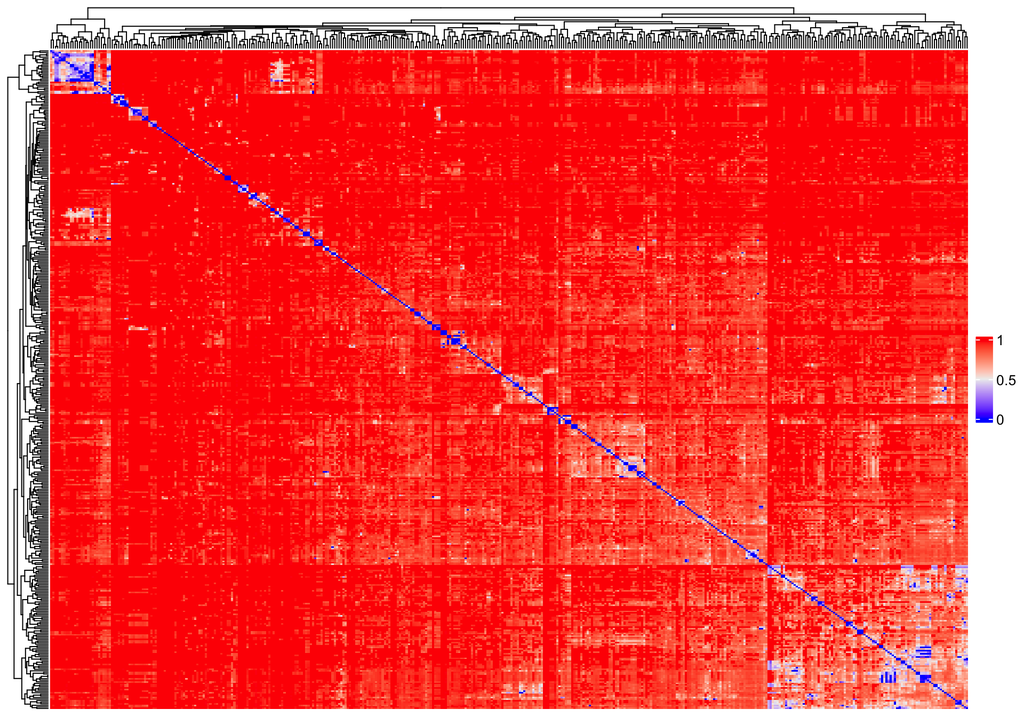

```r
# We first draw the pMM matrix and extract the row order of the clustered heatmap. This row order will later be used to ensure a consistent row order betwenn the two heatmaps to enable an easier comparison of the two results.
d <- distanceHeatmap(pmm_score, plot_labels = FALSE, title = "")
ht <- draw(d)
```

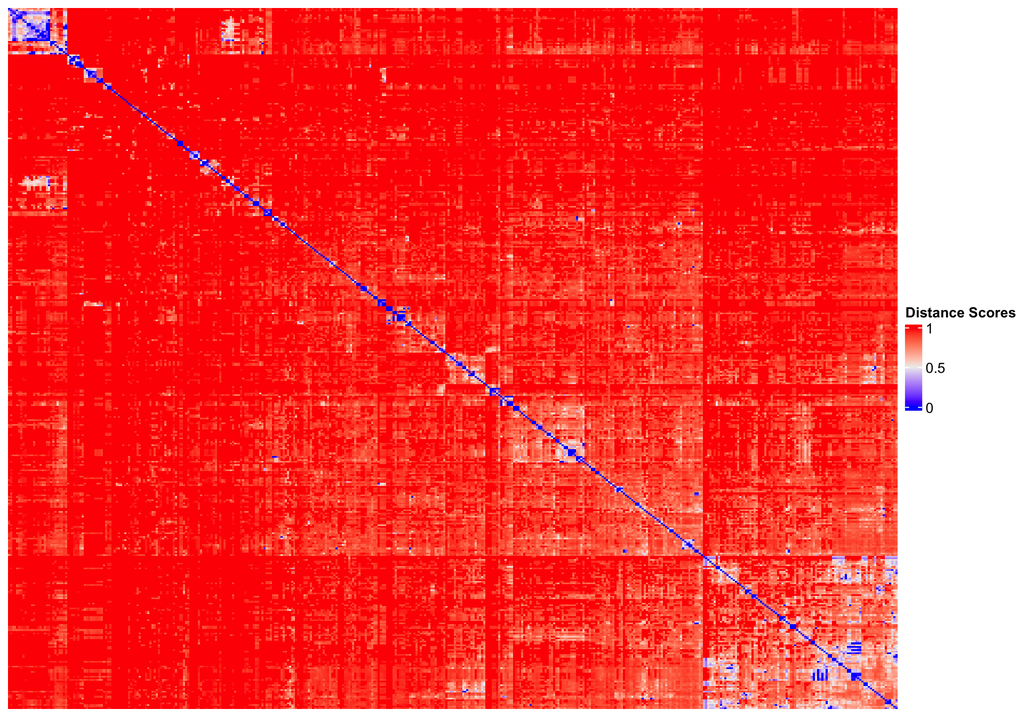

```r
row_order <- row_order(ht)


# Now we can plot both heatmaps with the same row order
GeDi::distanceHeatmap(pmm_score[row_order, row_order],
                      plot_labels = F,
                      cluster_rows = F,
                      cluster_columns = F,
                      title = "Distance Scores")
```

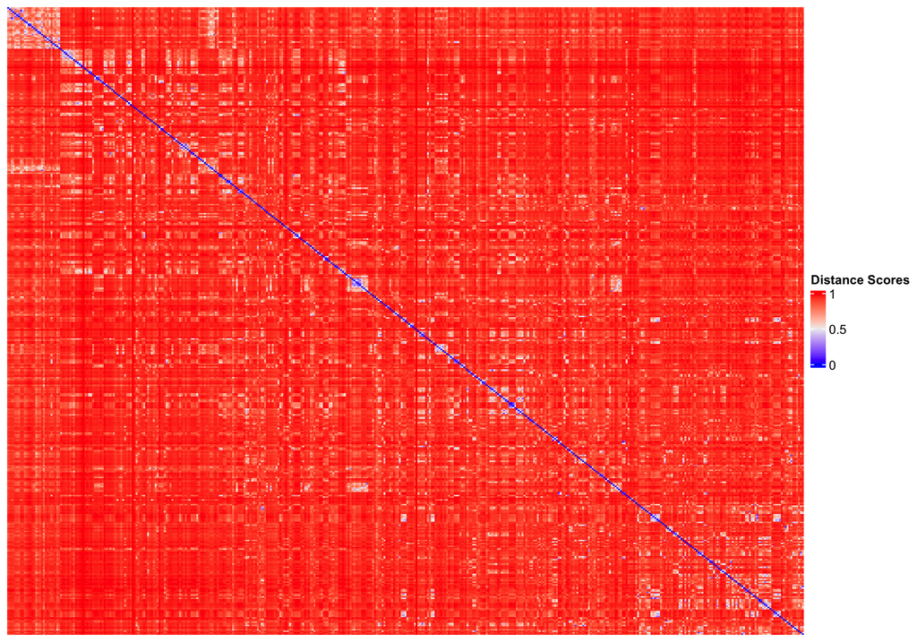

```r
GeDi::distanceHeatmap(go_score[row_order, row_order],
                      plot_labels = F,
                      cluster_rows = F,
                      cluster_columns = F,
                      title = "Distance Scores")
```

After we have calculated distance scores, we can cluster the data and visualize the results in as shown in Figure 2 C-F.

```r
# First we are clustering the data
pmm_louvain <- clustering(pmm_score,
                          threshold = 0.5,
                          cluster_method = "louvain")

pmm_fuzzy <- fuzzyClustering(seedFinding(pmm_score,
                                         simThreshold = 0.5,
                                         memThreshold = 0.5),
                             threshold = 0.5)

go_louvain <- clustering(go_score,
                         threshold = 0.5,
                         cluster_method = "louvain")

go_fuzzy <- fuzzyClustering(seedFinding(go_score,
                                        simThreshold = 0.5,
                                        memThreshold = 0.5),
                            threshold = 0.5)

# Next we can visualize the results of the clustering
g_pmm_louvain <- buildClusterGraph(pmm_louvain,
                                   genes,
                                   tregs_example_filtered$Genesets,
                                   color_by = "Cluster")

visNetwork::visIgraph(g_pmm_louvain) %>%
  visNodes(color = list(border = "#545454")) %>%
  visEdges(color = list(border = "#545454"), width = 10)
```

[interactive chart not shown]

```r
g_pmm_fuzzy <- buildClusterGraph(pmm_fuzzy,
                                 genes,
                                 tregs_example_filtered$Genesets,
                                 color_by = "Cluster")

visNetwork::visIgraph(g_pmm_fuzzy) %>%
  visNodes(color = list(border = "#545454")) %>%
  visEdges(color = list(border = "#545454"), width = 10)
```

[interactive chart not shown]

```r
g_go_louvain <- buildClusterGraph(go_louvain,
                                  genes,
                                  tregs_example_filtered$Genesets,
                                  color_by = "Cluster")

visNetwork::visIgraph(g_go_louvain) %>%
  visNodes(color = list(border = "#545454")) %>%
  visEdges(color = list(border = "#545454"), width = 10)
```

[interactive chart not shown]

```r
g_go_fuzzy <- buildClusterGraph(go_fuzzy,
                                genes,
                                tregs_example_filtered$Genesets,
                                color_by = "Cluster")

visNetwork::visIgraph(g_go_fuzzy) %>%
  visNodes(color = list(border = "#545454")) %>%
  visEdges(color = list(border = "#545454"), width = 10)
```

[interactive chart not shown]

We can also use the GeDi code to generate the wordclouds overlaid in Figure 2 E and F using the code below. For this, we first manually extracted the clusters belonging to the highlighted areas in E and F using an active GeDi session.

```r
# Wordcloud of Figure E

# Extract a cluster that represent T cell-related gene sets.
# The specific cluster indices were manually determined in a running `GeDi`
largeCellCluster <- unique(unlist(pmm_fuzzy[c(100, 33, 89, 122, 70, 73, 16, 61, 15, 10, 36, 97, 102, 105, 3, 45, 26, 50, 114, 110, 88, 6, 72, 38, 97, 101, 111, 116, 9, 63, 114, 107, 117, 91, 57, 46, 51, 30, 92, 17, 86, 118, 78, 83, 11, 104, 49, 22, 18, 119, 107, 1, 4, 9, 18, 23, 30, 48, 90, 99, 102, 107, 109, 119, 121, 46, 52, 53, 103, 104, 75)]))

# Generate a word cloud visualization for the T cell-related gene sets.
enrichmentWordcloud(tregs_example_filtered[largeCellCluster, ])
```

[interactive chart not shown]

```r
# Wordclouds in F
# Left side
tCellCluster <- unique(unlist(go_fuzzy[c(7, 8, 14, 17, 20, 24, 28, 30, 45, 49, 50, 58, 62, 64, 65, 70, 72, 76, 81, 85, 92, 96, 103, 105, 106, 112, 114, 121, 124)]))

enrichmentWordcloud(tregs_example_filtered[tCellCluster, ])
```

[interactive chart not shown]

```r
# Right side
proteinMembraneCluster <- unique(unlist(go_fuzzy[c(5, 6, 21, 23, 35, 43, 52, 54, 57, 69, 73, 80, 88, 102, 126)]))

enrichmentWordcloud(tregs_example_filtered[proteinMembraneCluster, ])
```

[interactive chart not shown]

# Bibliography

Alexa, Adrian, and Jorg Rahnenfuhrer. 2024. *topGO: Enrichment Analysis for Gene Ontology*.

Delacher, Michael, Charles D. Imbusch, Agnes Hotz-Wagenblatt, Jan Philipp Mallm, Katharina Bauer, Malte Simon, Dania Riegel, et al. 2020. “Precursors for Nonlymphoid-Tissue Treg Cells Reside in Secondary Lymphoid Organs and Are Programmed by the Transcription Factor BATF.” *Immunity* 52 (2): 295–312.e11. https://doi.org/10.1016/j.immuni.2019.12.002.

Love, Michael I., Wolfgang Huber, and Simon Anders. 2014. “Moderated Estimation of Fold Change and Dispersion for RNA-Seq Data with DESeq2.” *Genome Biology* 15: 550. https://doi.org/10.1186/s13059-014-0550-8.

Ludt, Annekathrin, Arsenij Ustjanzew, Harald Binder, Konstantin Strauch, and Federico Marini. 2022. “Interactive and Reproducible Workflows for Exploring and Modeling RNA-seq Data with pcaExplorer, Ideal, and GeneTonic.” *Current Protocols* 2 (4): 1–55. https://doi.org/10.1002/cpz1.411.

Marini, Federico, and Harald Binder. 2019. “pcaExplorer: an R/Bioconductor package for interacting with RNA-seq principal components.” *BMC Bioinformatics* 20 (1): 331. https://doi.org/10.1186/s12859-019-2879-1.

Marini, Federico, Jan Linke, and Harald Binder. 2020. “ideal: an R/Bioconductor package for interactive differential expression analysis.” *BMC Bioinformatics* 21 (1): 565. https://doi.org/10.1186/s12859-020-03819-5.